# R语言统计与建模

## 5.3 对数秩检验

### 意义与使用场景

**核心意义**：对数秩检验用于比较两组或多组生存曲线是否存在显著差异，是生存分析中最常用的假设检验方法。

**举例**：检验治疗组与对照组的生存曲线是否存在显著差异

**为什么这种数据适合用对数秩检验？**

首先，Kaplan-Meier曲线只能直观展示组间差异，无法判断差异是否具有统计学意义。其次，我们需要一种能够比较整个生存曲线（而非特定时间点）的方法。对数秩检验通过比较各组在每个事件时间点的观察死亡数与期望死亡数，检验生存曲线是否存在显著差异。

**研究目的是什么？**

本研究有三个层次的目的：1. 检验组间差异：判断治疗组与对照组的生存曲线是否存在显著差异；2. 计算检验统计量：获得卡方值和p值，做出统计推断；3. 报告结果：为临床决策提供统计学依据。

**可能得到什么样的结果？**

假设对数秩检验显示：卡方=8.5，自由度=1，p值=0.003。

1. 检验结果：p值=0.003<0.05，拒绝原假设，治疗组与对照组的生存曲线存在显著差异。
2. 效应方向：结合Kaplan-Meier曲线，治疗组的生存曲线位于对照组上方，说明治疗组生存情况更好。
3. 临床意义：治疗组中位生存时间比对照组延长1.4年，差异具有统计学意义和临床意义。
4. 亚组分析：可进一步按疾病分期分层进行对数秩检验，探索治疗效果在不同分期是否存在差异。

**需要注意什么？**

对数秩检验是比较整个生存曲线的方法，而非比较特定时间点的生存率。检验假设各组的风险函数成比例（比例风险假设），当假设不满足时，检验效能可能降低。对于多组比较，对数秩检验只能判断是否存在差异，无法识别哪些组之间存在差异，需要事后两两比较。

### 数学基础

**对数秩检验（Log-rank Test）**：

比较两组或多组生存曲线是否有差异。

**检验统计量**：
$$\chi^2 =
\frac{\left(\sum_{i}(O_{1i} -
E_{1i})\right)^2}{\sum_{i}V_i}$$

**参数说明**： - $O_{1i}$：第1组在$t_i$时刻的观察事件数 - $E_{1i}$：第1组在$t_i$时刻的期望事件数 - $V_i$：方差

### 代码实现

```r
# 对数秩检验：治疗组 vs 对照组
logrank <- survival::survdiff(surv_obj ~ treatment, data = surv_data)
cat("========== 对数秩检验（治疗组） ==========\n")
```

```
## ========== 对数秩检验（治疗组） ==========
```

```r
print(logrank)
```

```
## Call:
## survival::survdiff(formula = surv_obj ~ treatment, data = surv_data)
##
##                  N Observed Expected (O-E)^2/E (O-E)^2/V
## treatment=对照 103       67     48.4      7.16      13.7
## treatment=治疗  97       35     53.6      6.46      13.7
##
##  Chisq= 13.7  on 1 degrees of freedom, p= 2e-04
```

```r
# 对数秩检验：疾病分期
logrank_stage <- survival::survdiff(surv_obj ~ stage, data = surv_data)
cat("\n========== 对数秩检验（分期） ==========\n")
```

```
##
## ========== 对数秩检验（分期） ==========
```

```r
print(logrank_stage)
```

```
## Call:
## survival::survdiff(formula = surv_obj ~ stage, data = surv_data)
##
##              N Observed Expected (O-E)^2/E (O-E)^2/V
## stage=I期   72       32     42.0      2.36      4.05
## stage=II期  67       33     40.5      1.37      2.29
## stage=III期 61       37     19.6     15.47     19.69
##
##  Chisq= 19.8  on 2 degrees of freedom, p= 5e-05
```

```r
# 趋势检验
logrank_trend <- survival::survdiff(surv_obj ~ stage, data = surv_data, rho = 1)
cat("\n========== 趋势检验 ==========\n")
```

```
##
## ========== 趋势检验 ==========
```

```r
print(logrank_trend)
```

```
## Call:
## survival::survdiff(formula = surv_obj ~ stage, data = surv_data,
##     rho = 1)
##
##              N Observed Expected (O-E)^2/E (O-E)^2/V
## stage=I期   72     18.5     27.5      2.92      6.63
## stage=II期  67     21.7     26.9      1.02      2.26
## stage=III期 61     28.8     14.6     13.76     22.79
##
##  Chisq= 23.1  on 2 degrees of freedom, p= 9e-06
```

## 5.4 Cox比例风险模型

### 意义与使用场景

**核心意义**：Cox比例风险模型是生存分析中最重要的半参数模型，可同时分析多个协变量对生存时间的影响。

**举例**：研究年龄、治疗方式、疾病分期对癌症患者生存的影响

**为什么这种数据适合用Cox模型？**

首先，我们需要同时分析多个因素（年龄、治疗、分期）对生存的影响，控制混杂因素。其次，我们不知道生存时间的具体分布形式，不想做出强假设。Cox模型是半参数方法，不需要指定基线风险函数的形式，同时能够分析多个协变量的影响，是生存分析中最常用的多因素分析方法。

**研究目的是什么？**

本研究有三个层次的目的：1. 识别危险因素：判断哪些因素与生存时间显著相关；2. 量化风险程度：计算风险比（HR），回答”治疗组死亡风险是对照组的多少倍”；3. 控制混杂：在控制其他因素后，估计每个因素的独立效应。

**可能得到什么样的结果？**

假设Cox模型显示：年龄HR=1.05（p<0.001），治疗组HR=0.65（p=0.02），III期vs I期HR=2.5（p<0.001）。

1. 年龄效应：年龄每增加1岁，死亡风险增加5%；增加10岁风险增加63%。
2. 治疗效应：治疗组死亡风险是对照组的0.65倍（降低35%），治疗有效。
3. 分期效应：III期患者死亡风险是I期的2.5倍，分期是重要的预后因素。
4. 多因素分析：在控制年龄和分期后，治疗效果仍然显著，说明治疗有效。

**需要注意什么？**

Cox模型的核心假设是比例风险假设：风险比不随时间变化。若假设违反（如治疗效果随时间减弱），需使用分层Cox模型或引入时间协变量。风险比的解释需注意方向：HR>1表示风险增加，HR<1表示风险降低。此外，Cox模型不能直接预测生存概率，只能估计风险比。

### 数学基础

**Cox比例风险模型**：

$$h(t|\mathbf{X}) = h_0(t) \exp(\beta_1
X_1 + \beta_2 X_2 + \cdots + \beta_p X_p)$$

**参数说明**： - $h_0(t)$：基线风险函数（不指定形式） - $\exp(\beta_j)$：风险比（Hazard Ratio, HR）

**比例风险假设**：

任意两个体的风险比不随时间变化：
$$\frac{h(t|\mathbf{X}_1)}{h(t|\mathbf{X}_2)} =
\exp(\boldsymbol{\beta}'(\mathbf{X}_1 - \mathbf{X}_2))$$

**偏似然函数**：
$$L(\boldsymbol{\beta}) = \prod_{i=1}^{n}
\frac{\exp(\boldsymbol{\beta}'\mathbf{X}_i)}{\sum_{j \in R_i}
\exp(\boldsymbol{\beta}'\mathbf{X}_j)}$$

### 代码实现

```r
# 拟合Cox模型
cox_model <- survival::coxph(surv_obj ~ age + treatment + stage, data = surv_data)
summary(cox_model)
```

```
## Call:
## survival::coxph(formula = surv_obj ~ age + treatment + stage,
##     data = surv_data)
##
##   n= 200, number of events= 102
##
##                    coef exp(coef)  se(coef)      z Pr(>|z|)
## age            0.006428  1.006449  0.009952  0.646    0.518
## treatment治疗 -1.116084  0.327560  0.224974 -4.961 7.01e-07 ***
## stageII期      0.269636  1.309488  0.255023  1.057    0.290
## stageIII期     1.413932  4.112093  0.269329  5.250 1.52e-07 ***
## ---
## Signif. codes:  0 '***' 0.001 '**' 0.01 '*' 0.05 '.' 0.1 ' ' 1
##
##               exp(coef) exp(-coef) lower .95 upper .95
## age              1.0064     0.9936    0.9870    1.0263
## treatment治疗    0.3276     3.0529    0.2108    0.5091
## stageII期        1.3095     0.7637    0.7944    2.1586
## stageIII期       4.1121     0.2432    2.4255    6.9713
##
## Concordance= 0.67  (se = 0.029 )
## Likelihood ratio test= 43.39  on 4 df,   p=9e-09
## Wald test            = 42.07  on 4 df,   p=2e-08
## Score (logrank) test = 44.3  on 4 df,   p=6e-09
```

```r
# 提取风险比
hr_table <- broom::tidy(cox_model, exponentiate = TRUE, conf.int = TRUE)
cat("\n========== 风险比（HR）及95%%置信区间 ==========\n")
```

```
##
## ========== 风险比（HR）及95%%置信区间 ==========
```

```r
print(hr_table)
```

```
## # A tibble: 4 × 7
##   term          estimate std.error statistic     p.value conf.low conf.high
##   <chr>            <dbl>     <dbl>     <dbl>       <dbl>    <dbl>     <dbl>
## 1 age              1.01    0.00995     0.646 0.518          0.987     1.03
## 2 treatment治疗    0.328   0.225      -4.96  0.000000701    0.211     0.509
## 3 stageII期        1.31    0.255       1.06  0.290          0.794     2.16
## 4 stageIII期       4.11    0.269       5.25  0.000000152    2.43      6.97
```

```r
# 解释风险比
cat("\n========== 风险比解释 ==========\n")
```

```
##
## ========== 风险比解释 ==========
```

```r
cat(sprintf("年龄: HR = %.3f，年龄每增加1岁，死亡风险增加%.1f%%\n",
            hr_table$estimate[1], (hr_table$estimate[1] - 1) * 100))
```

```
## 年龄: HR = 1.006，年龄每增加1岁，死亡风险增加0.6%
```

```r
cat(sprintf("治疗: HR = %.3f，治疗组死亡风险是对照组的%.2f倍\n",
            hr_table$estimate[2], hr_table$estimate[2]))
```

```
## 治疗: HR = 0.328，治疗组死亡风险是对照组的0.33倍
```

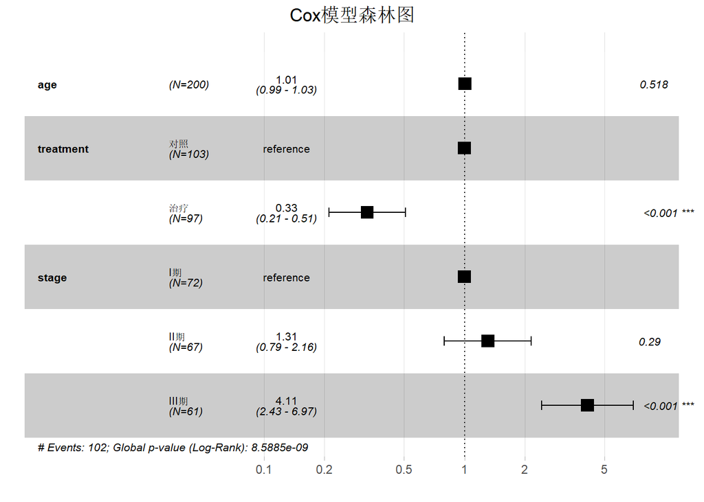

```r
# 绘制森林图
survminer::ggforest(cox_model, data = surv_data, main = "Cox模型森林图")
```

## 5.5 比例风险假设检验

### 意义与使用场景

**核心意义**：比例风险假设检验用于验证Cox模型的核心假设——风险比是否随时间保持恒定。

**举例**：检验治疗效果是否随时间变化

**为什么这种数据适合用比例风险假设检验？**

首先，Cox模型假设风险比不随时间变化，即治疗组与对照组的风险比在任何时间点都相同。其次，某些治疗可能存在时间依赖效应：治疗初期效果好，后期效果减弱（或增强）。比例风险假设检验能够识别这种违反假设的情况，确保模型结果的可靠性。

**研究目的是什么？**

本研究有三个层次的目的：1. 检验比例风险假设：判断Cox模型的核心假设是否满足；2. 识别违反假设的变量：判断哪些变量的风险比随时间变化；3. 指导模型修正：若假设违反，选择合适的处理方法（分层或时变协变量）。

**可能得到什么样的结果？**

假设Schoenfeld残差检验显示：年龄p=0.45，治疗p=0.02，分期p=0.68。

1. 年龄：p=0.45>0.05，比例风险假设满足，年龄的HR不随时间变化。
2. 治疗：p=0.02<0.05，比例风险假设违反，治疗效果随时间变化。
3. 分期：p=0.68>0.05，比例风险假设满足。
4. 残差图：治疗的Schoenfeld残差与时间呈负相关，提示治疗效果随时间减弱。

**需要注意什么？**

比例风险假设检验的p值<0.05表示假设违反，需要修正模型。修正方法包括：分层（按违反假设的变量分层）、时变协变量（引入时间交互项）、使用其他模型（如加速失效时间模型）。检验的敏感性受样本量影响：大样本可能检测到轻微违反，小样本可能漏检重要违反。

### 数学基础

**Schoenfeld残差检验**：

检验比例风险假设是否成立。

$$H_0:
\text{比例风险假设成立}$$

如果残差与时间存在系统性关系，则违反比例风险假设。

### 代码实现

```r
# Schoenfeld残差检验
ph_test <- survival::cox.zph(cox_model)
cat("========== 比例风险假设检验 ==========\n")
```

```
## ========== 比例风险假设检验 ==========
```

```r
print(ph_test)
```

```
##           chisq df    p
## age       0.838  1 0.36
## treatment 1.331  1 0.25
## stage     1.746  2 0.42
## GLOBAL    2.926  4 0.57
```

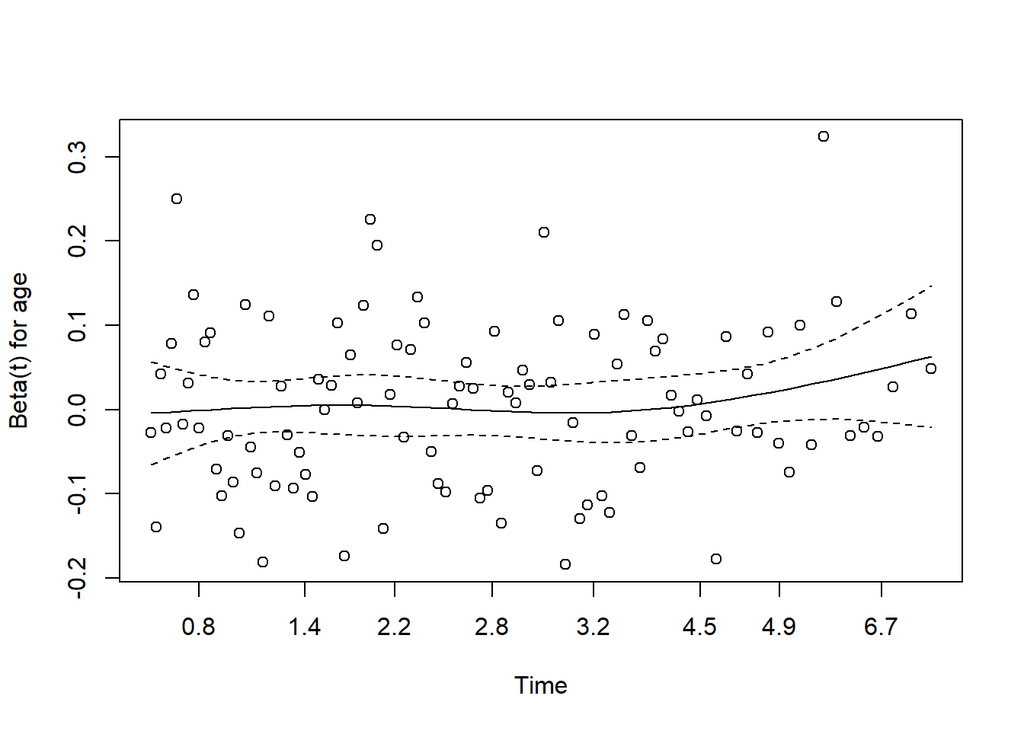

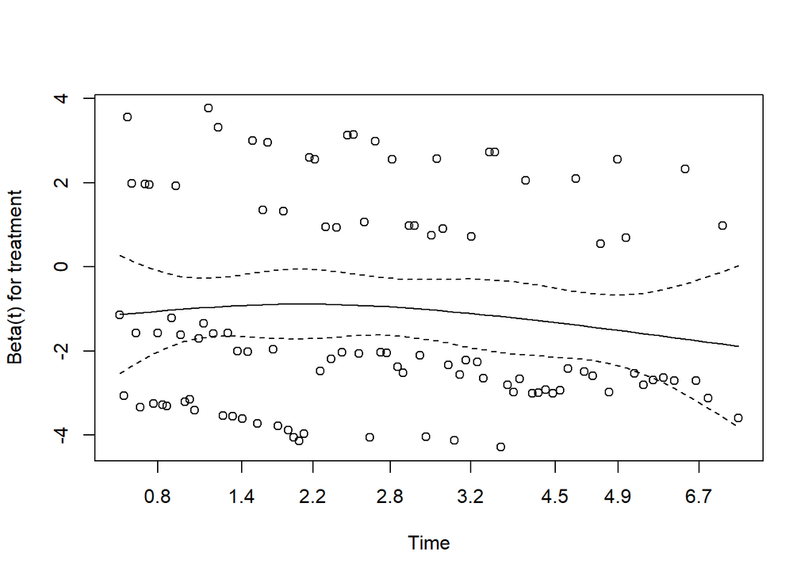

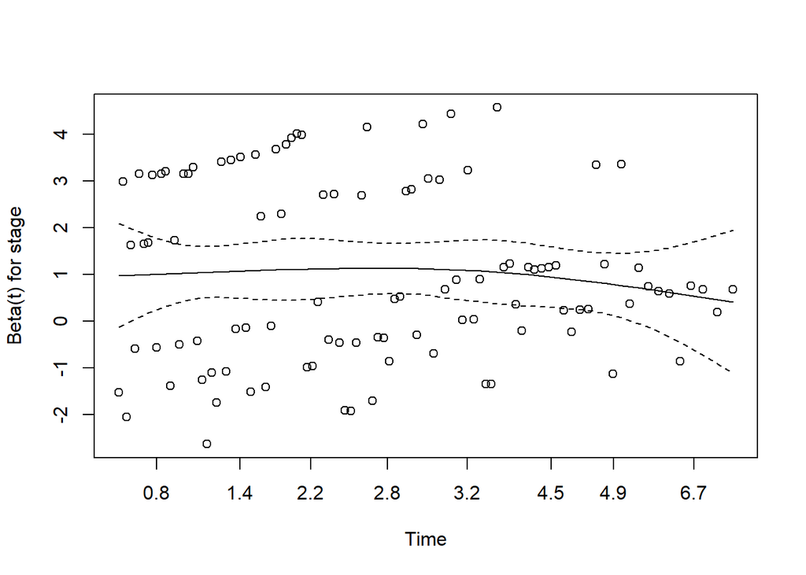

```r
# 绘制Schoenfeld残差图
plot(ph_test)
```

```r
# 如果违反比例风险假设，可以使用分层或时变协变量
# 分层Cox模型
cox_stratified <- survival::coxph(surv_obj ~ age + treatment + strata(stage),
                                   data = surv_data)
summary(cox_stratified)
```

```
## Call:
## survival::coxph(formula = surv_obj ~ age + treatment + strata(stage),
##     data = surv_data)
##
##   n= 200, number of events= 102
##
##                    coef exp(coef)  se(coef)      z Pr(>|z|)
## age            0.005124  1.005137  0.010103  0.507    0.612
## treatment治疗 -1.017969  0.361328  0.225858 -4.507 6.57e-06 ***
## ---
## Signif. codes:  0 '***' 0.001 '**' 0.01 '*' 0.05 '.' 0.1 ' ' 1
##
##               exp(coef) exp(-coef) lower .95 upper .95
## age              1.0051     0.9949    0.9854    1.0252
## treatment治疗    0.3613     2.7676    0.2321    0.5625
##
## Concordance= 0.596  (se = 0.035 )
## Likelihood ratio test= 21.91  on 2 df,   p=2e-05
## Wald test            = 20.34  on 2 df,   p=4e-05
## Score (logrank) test = 21.64  on 2 df,   p=2e-05
```

## 5.6 参数生存模型

### 意义与使用场景

**核心意义**：参数生存模型假设生存时间服从特定分布，可提供更精确的估计和预测，但需要正确指定分布形式。

**举例**：预测癌症患者的生存概率

**为什么这种数据适合用参数生存模型？**

首先，我们需要预测特定时间点的生存概率（如1年、3年、5年生存率），Cox模型需要额外估计基线风险。其次，根据既往研究，该疾病的生存时间大致服从Weibull分布。参数生存模型能够直接估计生存概率，提供更精确的预测，同时可以比较不同分布的拟合优度。

**研究目的是什么？**

本研究有三个层次的目的：1. 选择合适分布：比较指数、Weibull、对数正态等分布的拟合优度；2. 估计生存概率：预测特定时间点的生存概率和置信区间；3. 比较模型：通过AIC比较参数模型与Cox模型的拟合效果。

**可能得到什么样的结果？**

假设Weibull模型显示：形状参数γ=1.5，尺度参数λ=0.1，AIC=850（Cox模型AIC=865）。

1. 分布选择：Weibull分布AIC最小，拟合效果最好。
2. 风险函数：γ=1.5>1，风险随时间增加，早期风险较低，后期风险较高。
3. 生存预测：根据模型预测，1年生存率=88%，3年生存率=62%，5年生存率=45%。
4. 模型比较：Weibull模型AIC比Cox模型低15，说明参数模型拟合更好。

**需要注意什么？**

参数生存模型的结果依赖于分布假设的正确性。若分布假设错误，估计可能有偏。建议比较多种分布的拟合效果，选择AIC最小的分布。指数分布假设恒定风险，适用性有限；Weibull分布可建模单调风险，适用性较广；对数正态分布可建模非单调风险（先增后减）。

### 数学基础

**常见参数分布**：

| 分布 | 生存函数 | 风险函数 |
| --- | --- | --- |
| 指数 | $e^{-\lambda t}$ | $\lambda$（常数） |
| Weibull | $e^{-(\lambda t)^\gamma}$ | $\gamma\lambda(\lambda t)^{\gamma-1}$ |
| 对数正态 | $1-\Phi(\frac{\log t - \mu}{\sigma})$ | 非单调 |
| 对数逻辑 | $\frac{1}{1+(\lambda t)^\gamma}$ | 先增后减 |

### 代码实现

```r
# 指数分布模型
exp_model <- survival::survreg(surv_obj ~ age + treatment + stage,
                                data = surv_data, dist = "exponential")
summary(exp_model)
```

```
##
## Call:
## survival::survreg(formula = surv_obj ~ age + treatment + stage,
##     data = surv_data, dist = "exponential")
##                  Value Std. Error     z       p
## (Intercept)    2.18842    0.63988  3.42 0.00063
## age           -0.00706    0.00980 -0.72 0.47117
## treatment治疗  0.92201    0.21431  4.30 1.7e-05
## stageII期     -0.20314    0.25247 -0.80 0.42106
## stageIII期    -1.05120    0.24795 -4.24 2.2e-05
##
## Scale fixed at 1
##
## Exponential distribution
## Loglik(model)= -267.7   Loglik(intercept only)= -283.9
##  Chisq= 32.34 on 4 degrees of freedom, p= 1.6e-06
## Number of Newton-Raphson Iterations: 5
## n= 200
```

```r
# Weibull分布模型
weibull_model <- survival::survreg(surv_obj ~ age + treatment + stage,
                                    data = surv_data, dist = "weibull")
summary(weibull_model)
```

```
##
## Call:
## survival::survreg(formula = surv_obj ~ age + treatment + stage,
##     data = surv_data, dist = "weibull")
##                  Value Std. Error     z       p
## (Intercept)    1.93960    0.40996  4.73 2.2e-06
## age           -0.00453    0.00626 -0.72    0.47
## treatment治疗  0.71439    0.13920  5.13 2.9e-07
## stageII期     -0.16690    0.15792 -1.06    0.29
## stageIII期    -0.93342    0.15905 -5.87 4.4e-09
## Log(scale)    -0.47168    0.07689 -6.13 8.5e-10
##
## Scale= 0.624
##
## Weibull distribution
## Loglik(model)= -252.7   Loglik(intercept only)= -276.4
##  Chisq= 47.29 on 4 degrees of freedom, p= 1.3e-09
## Number of Newton-Raphson Iterations: 7
## n= 200
```

```r
# 对数正态分布模型
lognormal_model <- survival::survreg(surv_obj ~ age + treatment + stage,
                                      data = surv_data, dist = "lognormal")
summary(lognormal_model)
```

```
##
## Call:
## survival::survreg(formula = surv_obj ~ age + treatment + stage,
##     data = surv_data, dist = "lognormal")
##                   Value Std. Error     z       p
## (Intercept)    1.384748   0.460945  3.00  0.0027
## age           -0.000299   0.007279 -0.04  0.9672
## treatment治疗  0.637299   0.151300  4.21 2.5e-05
## stageII期     -0.156202   0.179554 -0.87  0.3843
## stageIII期    -0.848148   0.182196 -4.66 3.2e-06
## Log(scale)    -0.136441   0.071191 -1.92  0.0553
##
## Scale= 0.872
##
## Log Normal distribution
## Loglik(model)= -256   Loglik(intercept only)= -274
##  Chisq= 35.99 on 4 degrees of freedom, p= 2.9e-07
## Number of Newton-Raphson Iterations: 4
## n= 200
```

```r
# 模型比较
cat("\n========== 参数模型比较 ==========\n")
```

```
##
## ========== 参数模型比较 ==========
```

```r
cat(sprintf("指数模型 AIC: %.2f\n", AIC(exp_model)))
```

```
## 指数模型 AIC: 545.47
```

```r
cat(sprintf("Weibull模型 AIC: %.2f\n", AIC(weibull_model)))
```

```
## Weibull模型 AIC: 517.41
```

```r
cat(sprintf("对数正态模型 AIC: %.2f\n", AIC(lognormal_model)))
```

```
## 对数正态模型 AIC: 524.07
```

## 5.7 竞争风险模型

### 意义与使用场景

**核心意义**：竞争风险模型处理存在多种终点事件的情况，一种事件的发生会阻止其他事件的发生。

**举例**：研究癌症患者的复发和死亡风险

**为什么这种数据适合用竞争风险模型？**

首先，癌症患者可能发生两种终点事件：复发和死亡，且两者互为竞争风险：患者死亡后无法再观察到复发。其次，传统生存分析将其他事件视为删失，可能导致累积发生率估计偏高。竞争风险模型能够正确估计每种事件的累积发生率，是分析多终点事件的标准方法。

**研究目的是什么？**

本研究有三个层次的目的：1. 估计累积发生率：分别估计复发和死亡的累积发生率；2. 识别危险因素：分析哪些因素影响复发风险，哪些因素影响死亡风险；3. 比较组间差异：比较治疗组与对照组的累积发生率曲线。

**可能得到什么样的结果？**

假设竞争风险模型显示：治疗组复发风险SHR=0.65（p=0.03），死亡风险SHR=0.80（p=0.15）。

1. 复发风险：治疗组复发风险是对照组的0.65倍（降低35%），差异显著。
2. 死亡风险：治疗组死亡风险是对照组的0.80倍（降低20%），差异不显著。
3. 累积发生率：3年复发累积发生率治疗组=15%，对照组=25%；3年死亡累积发生率治疗组=10%，对照组=12%。
4. 临床意义：治疗主要降低复发风险，对死亡风险的影响较小。

**需要注意什么？**

竞争风险模型的结果解释需注意：累积发生率函数（CIF）与传统生存分析中的生存函数不同，CIF之和可能小于1（因为存在删失）。Fine-Gray模型估计的是亚分布风险比（SHR），与Cox模型的风险比（HR）解释不同。当竞争事件发生率较高时，竞争风险模型与传统生存分析的结果差异较大。

### 数学基础

**竞争风险**：

当存在多种可能的事件类型，且一种事件的发生会阻止其他事件发生时。

**原因别风险函数**：
$$h_k(t)
= \lim_{\Delta t \to 0} \frac{P(t \leq T < t + \Delta t, K = k | T
\geq t)}{\Delta t}$$

**累积发生率函数（CIF）**：
$$F_k(t) = P(T \leq t, K = k) = \int_0^t
h_k(u)S(u)du$$

### 代码实现

```r
# 模拟竞争风险数据
set.seed(666)
n_cr <- 200

age_cr <- rnorm(n_cr, 60, 10)
treatment_cr <- rbinom(n_cr, 1, 0.5)

# 生成两种竞争事件：复发和死亡
# 基线风险
lambda_relapse <- 0.1 * exp(0.02 * age_cr - 0.3 * treatment_cr)
lambda_death <- 0.05 * exp(0.03 * age_cr)

# 生成事件时间
time_relapse <- rexp(n_cr, lambda_relapse)
time_death <- rexp(n_cr, lambda_death)

# 观察到的事件
obs_time <- pmin(time_relapse, time_death)
event_type <- ifelse(time_relapse < time_death, 1, 2)  # 1=复发, 2=死亡

# 创建数据框
cr_data <- data.frame(
  age = age_cr,
  treatment = factor(treatment_cr, levels = c(0, 1), labels = c("对照", "治疗")),
  time = obs_time,
  status = event_type
)

# 使用cmprsk包进行分析
library(cmprsk)

# Fine-Gray模型
fg_model <- cmprsk::crr(cr_data$time, cr_data$status,
                         cov1 = model.matrix(~ age + treatment, cr_data)[, -1])
summary(fg_model)
```

```
## Competing Risks Regression
##
## Call:
## cmprsk::crr(ftime = cr_data$time, fstatus = cr_data$status, cov1 = model.matrix(~age +
##     treatment, cr_data)[, -1])
##
##                   coef exp(coef) se(coef)      z p-value
## age           -0.00179     0.998  0.00929 -0.193  0.8500
## treatment治疗 -0.68100     0.506  0.21645 -3.146  0.0017
##
##               exp(coef) exp(-coef)  2.5% 97.5%
## age               0.998       1.00 0.980 1.017
## treatment治疗     0.506       1.98 0.331 0.774
##
## Num. cases = 200
## Pseudo Log-likelihood = -480
## Pseudo likelihood ratio test = 10.5  on 2 df,
```

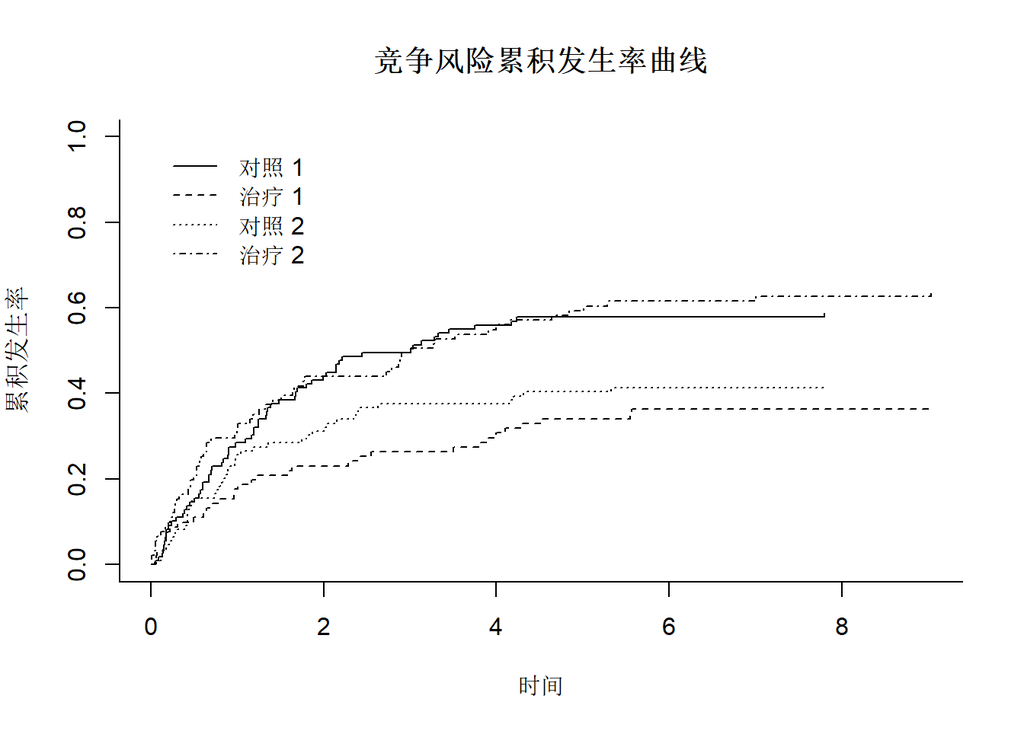

```r
# 累积发生率曲线
cif_fit <- cmprsk::cuminc(cr_data$time, cr_data$status, cr_data$treatment)
plot(cif_fit, xlab = "时间", ylab = "累积发生率", main = "竞争风险累积发生率曲线")
```

## 第五章小结

### 核心知识点总结

| 主题 | 核心内容 | 关键函数 |
| --- | --- | --- |
| 生存函数 | 生存概率随时间变化 | `Surv()` |
| Kaplan-Meier | 非参数生存估计 | `survfit()` |
| 对数秩检验 | 比较生存曲线 | `survdiff()` |
| Cox模型 | 半参数回归 | `coxph()` |
| 比例风险检验 | Schoenfeld残差 | `cox.zph()` |
| 参数模型 | 指数、Weibull等 | `survreg()` |
| 竞争风险 | 多种事件类型 | `crr()`, `cuminc()` |

# 第六章：多元统计分析

多元统计分析用于研究多个变量之间的关系，包括降维、分类、聚类等方法。本章将系统讲解主成分分析、因子分析、聚类分析、判别分析等核心方法。

## 6.1 主成分分析

### 意义与使用场景

**核心意义**：主成分分析（PCA）是一种降维技术，将多个相关变量转换为少数几个不相关的主成分，简化数据结构。

**举例**：从多个健康指标中提取综合健康指数

**为什么这种数据适合用主成分分析？**

首先，我们有多个健康指标（血压、BMI、血糖、胆固醇等），这些指标之间存在相关性，信息有重叠。其次，我们需要一个综合指标来评估整体健康状况，便于后续分析和可视化。主成分分析能够将多个相关变量转换为少数几个不相关的主成分，提取主要信息，简化数据结构。

**研究目的是什么？**

本研究有三个层次的目的：1. 数据降维：将多个健康指标转换为少数几个主成分；2. 提取综合指标：用第一主成分作为综合健康指数；3. 简化后续分析：用主成分代替原始变量进行回归或聚类分析。

**可能得到什么样的结果？**

假设主成分分析显示：第一主成分解释方差40%，第二主成分解释方差25%，累计解释方差65%。

1. 第一主成分：载荷显示血压、血糖、胆固醇载荷较高，命名为”代谢综合征指数”。
2. 第二主成分：载荷显示BMI、血压载荷较高，命名为”肥胖相关指数”。
3. 累计解释方差：前两个主成分解释了65%的总变异，信息损失可接受。
4. 综合健康指数：第一主成分得分可作为综合健康指数，得分越高表示代谢风险越高。

**需要注意什么？**

主成分分析对变量的量纲敏感，不同量纲的变量会导致结果偏向方差大的变量。建议在分析前对变量进行标准化（Z-score标准化）。主成分的解释需要结合载荷矩阵，载荷绝对值越大，该变量对主成分的贡献越大。主成分数量可通过累计解释方差（如>70%）或特征值>1准则确定。

### 数学基础

**主成分分析（PCA）**：

将多个相关变量转换为少数几个不相关的主成分。

**数学定义**：

寻找线性组合：
$$PC_1 = a_{11}X_1 +
a_{12}X_2 + \cdots + a_{1p}X_p$$

使得$Var(PC_1)$最大，且满足$a_{11}^2 + a_{12}^2 + \cdots + a_{1p}^2 = 1$。

**协方差矩阵分解**：

$$\mathbf{S} =
\mathbf{A}\mathbf{\Lambda}\mathbf{A}'$$

**参数说明**： - $\mathbf{S}$：协方差矩阵 - $\mathbf{A}$：特征向量矩阵（载荷） - $\mathbf{\Lambda}$：特征值对角矩阵

**方差解释率**：
$$\text{解释率}_k =
\frac{\lambda_k}{\sum_{j=1}^{p}\lambda_j}$$

### 代码实现

```r
# 模拟健康指标数据
set.seed(777)
n_pca <- 200

# 生成相关的健康指标
sbp <- rnorm(n_pca, 120, 15)          # 收缩压
dbp <- 0.6 * sbp + rnorm(n_pca, 30, 8) # 舒张压（与收缩压相关）
bmi <- rnorm(n_pca, 25, 4)             # BMI
glucose <- 0.3 * bmi + rnorm(n_pca, 90, 15)  # 血糖（与BMI相关）
cholesterol <- rnorm(n_pca, 200, 40)   # 胆固醇
triglyceride <- 0.4 * cholesterol + rnorm(n_pca, 50, 30)  # 甘油三酯
crp <- rnorm(n_pca, 3, 2)              # C反应蛋白

health_data <- data.frame(
  sbp = sbp, dbp = dbp, bmi = bmi,
  glucose = glucose, cholesterol = cholesterol,
  triglyceride = triglyceride, crp = crp
)

# 查看相关矩阵
cor_matrix <- cor(health_data)
cat("========== 相关矩阵 ==========\n")
```

```
## ========== 相关矩阵 ==========
```

```r
print(round(cor_matrix, 3))
```

```
##                 sbp    dbp    bmi glucose cholesterol triglyceride    crp
## sbp           1.000  0.704 -0.099   0.069       0.014       -0.018  0.032
## dbp           0.704  1.000 -0.106   0.085       0.015        0.041  0.058
## bmi          -0.099 -0.106  1.000   0.149      -0.049       -0.081 -0.022
## glucose       0.069  0.085  0.149   1.000      -0.109       -0.103 -0.021
## cholesterol   0.014  0.015 -0.049  -0.109       1.000        0.454  0.019
## triglyceride -0.018  0.041 -0.081  -0.103       0.454        1.000 -0.004
## crp           0.032  0.058 -0.022  -0.021       0.019       -0.004  1.000
```

```r
# 主成分分析
pca_result <- prcomp(health_data, scale. = TRUE, center = TRUE)

# 查看结果
summary(pca_result)
```

```
## Importance of components:
##                          PC1    PC2    PC3    PC4    PC5     PC6     PC7
## Standard deviation     1.323 1.2372 1.0387 0.9953 0.9009 0.74000 0.53938
## Proportion of Variance 0.250 0.2187 0.1541 0.1415 0.1160 0.07823 0.04156
## Cumulative Proportion  0.250 0.4686 0.6227 0.7642 0.8802 0.95844 1.00000
```

```r
# 特征值和方差解释
eigenvalues <- pca_result$sdev^2
var_explained <- eigenvalues / sum(eigenvalues)
cum_var <- cumsum(var_explained)

pca_summary <- data.frame(
  PC = 1:length(eigenvalues),
  Eigenvalue = eigenvalues,
  Variance = var_explained,
  Cumulative = cum_var
)
cat("\n========== 方差解释 ==========\n")
```

```
##
## ========== 方差解释 ==========
```

```r
print(round(pca_summary, 4))
```

```
##   PC Eigenvalue Variance Cumulative
## 1  1     1.7497   0.2500     0.2500
## 2  2     1.5306   0.2187     0.4686
## 3  3     1.0789   0.1541     0.6227
## 4  4     0.9906   0.1415     0.7643
## 5  5     0.8117   0.1160     0.8802
## 6  6     0.5476   0.0782     0.9584
## 7  7     0.2909   0.0416     1.0000
```

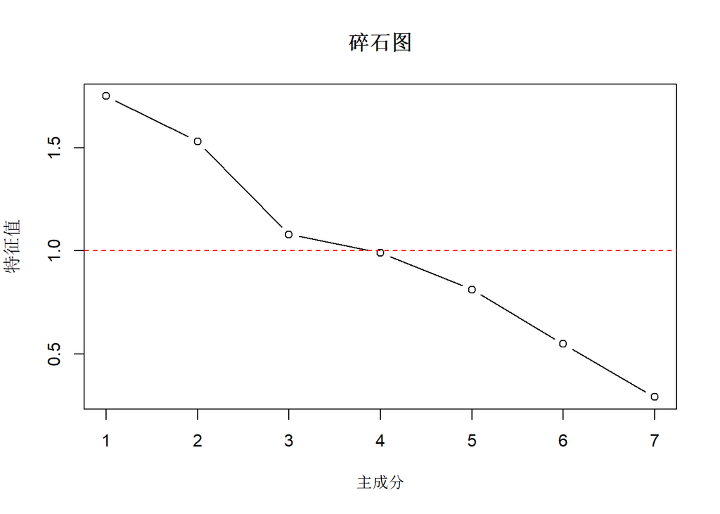

```r
# 碎石图
plot(eigenvalues, type = "b", main = "碎石图",
     xlab = "主成分", ylab = "特征值")
abline(h = 1, col = "red", lty = 2)
```

```r
# 载荷矩阵
loadings <- pca_result$rotation
cat("\n========== 载荷矩阵 ==========\n")
```

```
##
## ========== 载荷矩阵 ==========
```

```r
print(round(loadings[, 1:3], 3))
```

```
##                 PC1    PC2    PC3
## sbp           0.682 -0.096  0.028
## dbp           0.689 -0.067  0.047
## bmi          -0.187 -0.223  0.645
## glucose       0.081 -0.343  0.601
## cholesterol   0.075  0.637  0.294
## triglyceride  0.075  0.643  0.273
## crp           0.087  0.027 -0.243
```

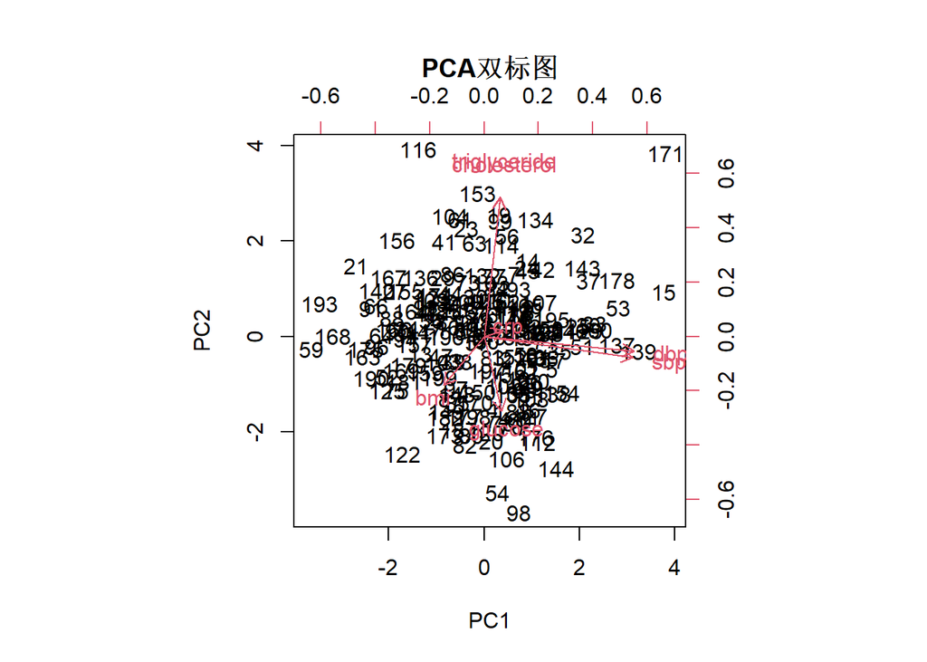

```r
# 主成分得分
scores <- pca_result$x

# 绘制双标图
biplot(pca_result, scale = 0, main = "PCA双标图")
```

## 6.2 因子分析

### 意义与使用场景

**核心意义**：因子分析用于探索观测变量背后的潜在因子结构，揭示变量间的潜在关系。

**举例**：心理量表开发中提取潜在心理维度

**为什么这种数据适合用因子分析？**

首先，心理量表包含多个条目（如”我感到焦虑”、“我难以入睡”等），这些条目可能反映几个潜在的心理维度（如焦虑、抑郁）。其次，我们需要探索量表的结构效度，验证条目是否按预期归入不同因子。因子分析能够揭示观测变量背后的潜在因子结构，是量表开发和验证的标准方法。

**研究目的是什么？**

本研究有三个层次的目的：1. 探索因子结构：确定量表包含几个潜在因子；2. 验证条目归属：判断每个条目归属于哪个因子；3. 评估量表质量：计算因子载荷和共同度，评估条目质量。

**可能得到什么样的结果？**

假设因子分析显示：提取2个因子，累计解释方差55%，因子间相关r=0.4。

1. 因子结构：条目1-5在因子1上载荷较高（>0.6），命名为”焦虑因子”；条目6-10在因子2上载荷较高，命名为”抑郁因子”。
2. 因子载荷：大部分条目的因子载荷>0.5，说明条目与因子的关联较强。
3. 共同度：大部分条目的共同度>0.4，说明条目的变异能被因子较好地解释。
4. 因子相关：两因子相关r=0.4，说明焦虑和抑郁存在中等程度相关。

**需要注意什么？**

因子分析需要足够的样本量，一般建议样本量至少为变量数的5-10倍。因子数量可通过平行分析、特征值>1准则或理论预期确定。正交旋转（Varimax）假设因子不相关，斜交旋转（Promax）允许因子相关，实际应用中斜交旋转更符合心理现象。

### 数学基础

**因子分析模型**：

$$\mathbf{X} = \mathbf{\Lambda}\mathbf{F}
+ \mathbf{\varepsilon}$$

**参数说明**： - $\mathbf{X}$：观测变量 - $\mathbf{\Lambda}$：因子载荷矩阵 - $\mathbf{F}$：公共因子 - $\mathbf{\varepsilon}$：特殊因子（误差）

**因子旋转**：

| 方法 | 特点 |
| --- | --- |
| 方差最大旋转（Varimax） | 正交旋转，简化载荷 |
| 斜交旋转（Promax/Oblimin） | 允许因子相关 |

**因子得分**：

估计个体在公共因子上的值。

### 代码实现

```r
# 探索性因子分析
library(psych)

# 确定因子数量
fa_parallel <- psych::fa.parallel(health_data, fa = "fa", main = "平行分析")
```

[figure not shown]

```
## Parallel analysis suggests that the number of factors =  2  and the number of components =  NA
```

```r
# 提取2个因子
fa_result <- psych::fa(health_data, nfactors = 2, rotate = "varimax", fm = "ml")

# 查看结果
print(fa_result)
```

```
## Factor Analysis using method =  ml
## Call: psych::fa(r = health_data, nfactors = 2, rotate = "varimax",
##     fm = "ml")
## Standardized loadings (pattern matrix) based upon correlation matrix
##                ML1   ML2     h2    u2 com
## sbp           0.73 -0.09 0.5383 0.462 1.0
## dbp           0.96 -0.06 0.9242 0.076 1.0
## bmi          -0.12 -0.10 0.0240 0.976 1.9
## glucose       0.08 -0.17 0.0348 0.965 1.4
## cholesterol   0.06  0.61 0.3719 0.628 1.0
## triglyceride  0.09  0.74 0.5496 0.450 1.0
## crp           0.06  0.00 0.0035 0.997 1.0
##
##                        ML1  ML2
## SS loadings           1.49 0.96
## Proportion Var        0.21 0.14
## Cumulative Var        0.21 0.35
## Proportion Explained  0.61 0.39
## Cumulative Proportion 0.61 1.00
##
## Mean item complexity =  1.2
## Test of the hypothesis that 2 factors are sufficient.
##
## df null model =  21  with the objective function =  0.99 with Chi Square =  194.64
## df of  the model are 8  and the objective function was  0.03
##
## The root mean square of the residuals (RMSR) is  0.03
## The df corrected root mean square of the residuals is  0.05
##
## The harmonic n.obs is  200 with the empirical chi square  4.68  with prob <  0.79
## The total n.obs was  200  with Likelihood Chi Square =  5.77  with prob <  0.67
##
## Tucker Lewis Index of factoring reliability =  1.034
## RMSEA index =  0  and the 90 % confidence intervals are  0 0.066
## BIC =  -36.62
## Fit based upon off diagonal values = 0.97
## Measures of factor score adequacy
##                                                    ML1  ML2
## Correlation of (regression) scores with factors   0.96 0.81
## Multiple R square of scores with factors          0.93 0.65
## Minimum correlation of possible factor scores     0.86 0.30
```

```r
# 因子载荷
cat("\n========== 因子载荷 ==========\n")
```

```
##
## ========== 因子载荷 ==========
```

```r
print(round(fa_result$loadings, 3))
```

```
##
## Loadings:
##              ML1    ML2
## sbp           0.729
## dbp           0.960
## bmi          -0.119 -0.100
## glucose             -0.170
## cholesterol          0.607
## triglyceride         0.736
## crp
##
##                  ML1   ML2
## SS loadings    1.487 0.960
## Proportion Var 0.212 0.137
## Cumulative Var 0.212 0.350
```

```r
# 方差解释
cat("\n========== 方差解释 ==========\n")
```

```
##
## ========== 方差解释 ==========
```

```r
print(fa_result$Vaccounted)
```

```
##                             ML1       ML2
## SS loadings           1.4854592 0.9607829
## Proportion Var        0.2122085 0.1372547
## Cumulative Var        0.2122085 0.3494632
## Proportion Explained  0.6072413 0.3927587
## Cumulative Proportion 0.6072413 1.0000000
```

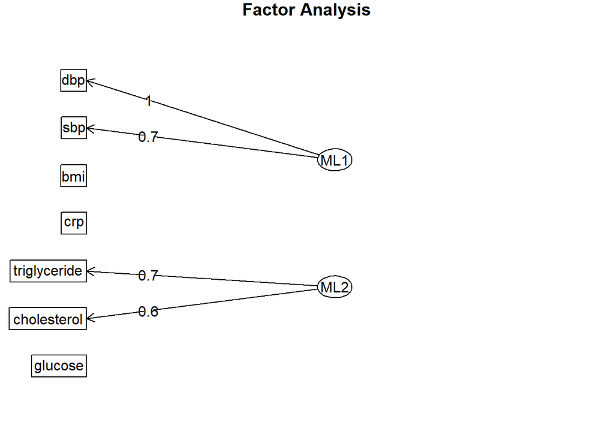

```r
# 绘制因子载荷图
psych::fa.diagram(fa_result)
```

```r
# 斜交旋转
fa_oblique <- psych::fa(health_data, nfactors = 2, rotate = "promax", fm = "ml")
cat("\n========== 斜交旋转因子载荷 ==========\n")
```

```
##
## ========== 斜交旋转因子载荷 ==========
```

```r
print(round(fa_oblique$loadings, 3))
```

```
##
## Loadings:
##              ML1    ML2
## sbp           0.733 -0.115
## dbp           0.964
## bmi          -0.115
## glucose             -0.173
## cholesterol          0.606
## triglyceride         0.735
## crp
##
##                  ML1   ML2
## SS loadings    1.495 0.969
## Proportion Var 0.214 0.138
## Cumulative Var 0.214 0.352
```

```r
# 因子间相关
cat("\n========== 因子间相关 ==========\n")
```

```
##
## ========== 因子间相关 ==========
```

```r
print(round(fa_oblique$Phi, 3))
```

```
##       ML1   ML2
## ML1 1.000 0.073
## ML2 0.073 1.000
```

```r
# 计算因子得分
factor_scores <- factor.scores(health_data, fa_result)
head(factor_scores$scores)
```

```
##             ML1         ML2
## [1,]  0.2371443 -1.21209869
## [2,]  0.5687909 -0.49879278
## [3,]  0.3364426  0.82119205
## [4,] -0.5301159  0.01436721
## [5,]  0.7783406 -0.57864714
## [6,] -0.2129023 -0.09287515
```

## 6.3 聚类分析

### 意义与使用场景

**核心意义**：聚类分析将相似的观测对象分组，发现数据中的自然分组结构，是无监督学习的核心方法。

**举例**：糖尿病患者亚型识别

**为什么这种数据适合用聚类分析？**

首先，糖尿病是一种异质性疾病，可能存在不同的亚型，但亚型数量和特征未知。其次，我们有多个临床指标（年龄、BMI、血糖、胰岛素水平等），需要根据这些指标将患者分组。聚类分析是无监督学习方法，能够在没有预先定义类别的情况下，发现数据中的自然分组结构。

**研究目的是什么？**

本研究有三个层次的目的：1. 发现亚型：识别糖尿病患者中是否存在不同的亚型；2. 描述亚型特征：分析各亚型在临床指标上的差异；3. 临床应用：为精准医疗提供依据，不同亚型可能需要不同的治疗方案。

**可能得到什么样的结果？**

假设聚类分析显示：最优聚类数为3，轮廓系数=0.65。

1. 亚型1（经典型）：年龄较大、BMI正常、胰岛素分泌减少，占40%。
2. 亚型2（肥胖相关型）：年龄较轻、BMI较高、胰岛素抵抗明显，占35%。
3. 亚型3（轻度肥胖型）：年龄中等、BMI轻度升高、代谢指标相对较好，占25%。
4. 临床意义：亚型2可能需要更积极的减重干预，亚型1可能需要更早启动胰岛素治疗。

**需要注意什么？**

聚类分析的结果依赖于距离度量（如欧氏距离、马氏距离）和聚类方法（如层次聚类、K-means）。不同方法可能得到不同的结果，建议尝试多种方法并比较。聚类数量可通过轮廓系数、肘部法则或Gap统计量确定。聚类结果需要结合专业知识解释，确保分型具有临床意义。

### 数学基础

**层次聚类**：

自底向上（凝聚）或自顶向下（分裂）构建聚类树。

**距离度量**：
$$d_{ij} =
\sqrt{\sum_{k=1}^{p}(x_{ik} - x_{jk})^2} \quad
\text{（欧氏距离）}$$

**链接方法**：

| 方法 | 定义 |
| --- | --- |
| 单链接 | 类间最小距离 |
| 全链接 | 类间最大距离 |
| 平均链接 | 类间平均距离 |
| Ward方法 | 最小化类内方差 |

**K-means聚类**：

最小化类内平方和：
$$W(C) =
\sum_{k=1}^{K}\sum_{i \in C_k} ||\mathbf{x}_i -
\boldsymbol{\mu}_k||^2$$

### 代码实现

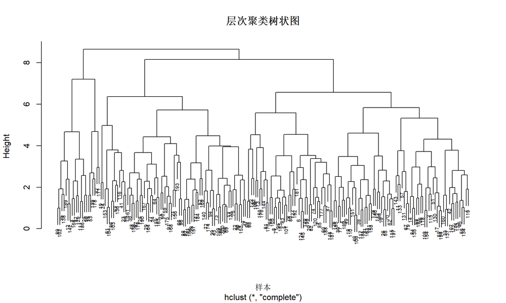

```r
# 标准化数据
health_scaled <- scale(health_data)

# 层次聚类
dist_matrix <- dist(health_scaled, method = "euclidean")
hc_complete <- hclust(dist_matrix, method = "complete")

# 绘制树状图
plot(hc_complete, main = "层次聚类树状图", xlab = "样本", cex = 0.6)
```

```r
# 切割树状图
clusters_hc <- cutree(hc_complete, k = 3)
table(clusters_hc)
```

```
## clusters_hc
##   1   2   3
## 108  21  71
```

```r
# K-means聚类
set.seed(888)
km_result <- kmeans(health_scaled, centers = 3, nstart = 25)

# 查看结果
cat("========== K-means聚类结果 ==========\n")
```

```
## ========== K-means聚类结果 ==========
```

```r
print(km_result$centers)
```

```
##          sbp        dbp         bmi    glucose cholesterol triglyceride
## 1  0.2950832  0.3057690  0.38234893  0.7806327  -0.8965902   -0.9658988
## 2  0.8076646  0.7328541 -0.30581313 -0.1847194   0.4423954    0.4182768
## 3 -0.8828170 -0.8235747  0.04148128 -0.3006827   0.1435340    0.2057467
##            crp
## 1  0.142779377
## 2 -0.105916114
## 3  0.008230049
```

```r
cat("\n各类别样本数：\n")
```

```
##
## 各类别样本数：
```

```r
print(table(km_result$cluster))
```

```
##
##  1  2  3
## 48 71 81
```

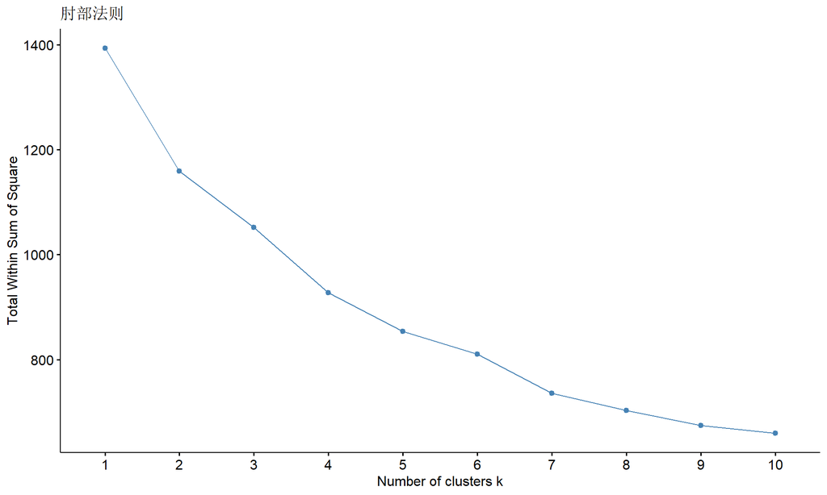

```r
# 确定最优聚类数
library(factoextra)
fviz_nbclust(health_scaled, kmeans, method = "wss") +
  ggplot2::labs(title = "肘部法则")
```

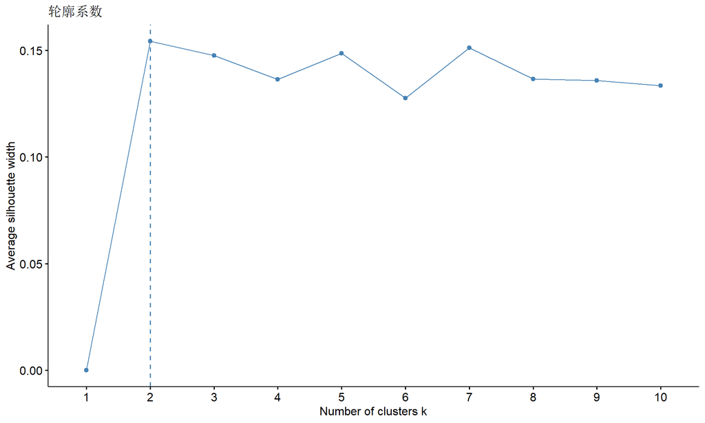

```r
fviz_nbclust(health_scaled, kmeans, method = "silhouette") +
  ggplot2::labs(title = "轮廓系数")
```

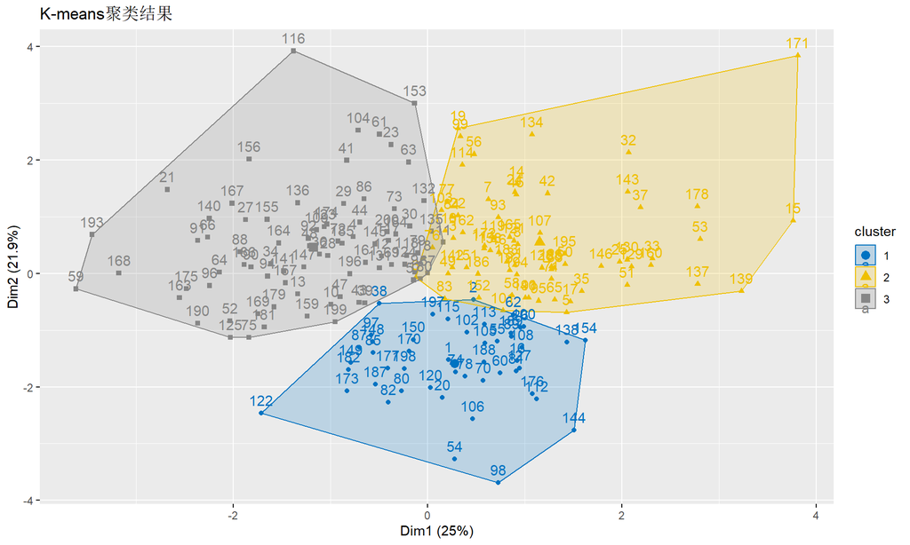

```r
# 可视化聚类结果
fviz_cluster(km_result, data = health_scaled,
             palette = "jco", ellipse.type = "convex",
             main = "K-means聚类结果")
```

```r
# 比较两种聚类方法
cat("\n========== 聚类方法比较 ==========\n")
```

```
##
## ========== 聚类方法比较 ==========
```

```r
cat("调整兰德指数（ARI）：\n")
```

```
## 调整兰德指数（ARI）：
```

```r
library(mclust)
ari <- mclust::adjustedRandIndex(clusters_hc, km_result$cluster)
cat(sprintf("ARI = %.3f\n", ari))
```

```
## ARI = 0.266
```

## 6.4 判别分析

### 意义与使用场景

**核心意义**：判别分析用于根据多个变量对观测对象进行分类，是有监督的分类方法。

**举例**：良性与恶性肿瘤的鉴别诊断

**为什么这种数据适合用判别分析？**

首先，我们有已知的肿瘤类型标签（良性/恶性），需要建立分类规则。其次，我们有多个诊断指标（肿瘤大小、形状、边界、密度等），需要综合这些指标进行判断。判别分析能够根据已知类别的样本，建立最优的分类规则，对新样本进行分类，是医学诊断的常用方法。

**研究目的是什么？**

本研究有三个层次的目的：1. 建立分类规则：根据多个指标建立肿瘤良恶性的判别函数；2. 评估分类准确性：计算训练集和测试集的分类准确率；3. 识别关键指标：判断哪些指标对分类贡献最大。

**可能得到什么样的结果？**

假设LDA模型显示：整体准确率=92%，敏感性=88%，特异性=95%。

1. 判别函数：LD1 = 0.5×肿瘤大小 + 0.8×边界不规则度 - 0.3×密度，LD1是主要的判别维度。
2. 分类准确性：整体准确率92%，良性肿瘤识别率95%，恶性肿瘤识别率88%。
3. 关键指标：边界不规则度对判别贡献最大，其次是肿瘤大小。
4. 临床应用：判别函数可用于辅助诊断，但需结合临床经验。

**需要注意什么？**

LDA假设各组协方差矩阵相等，若假设违反需使用QDA。判别分析的结果需要用独立测试集验证，避免过拟合。对于不平衡数据，准确率可能误导，应关注敏感性和特异性。判别分析假设自变量服从多元正态分布，严重偏离时可能影响结果。

### 数学基础

**线性判别分析（LDA）**：

寻找线性组合最大化组间方差与组内方差之比。

$$\max_{\mathbf{a}}
\frac{\mathbf{a}'\mathbf{B}\mathbf{a}}{\mathbf{a}'\mathbf{W}\mathbf{a}}$$

**参数说明**： - $\mathbf{B}$：组间协方差矩阵 - $\mathbf{W}$：组内协方差矩阵

**判别函数**：
$$\delta_k(\mathbf{x}) =
\mathbf{x}'\mathbf{W}^{-1}\boldsymbol{\mu}_k -
\frac{1}{2}\boldsymbol{\mu}_k'\mathbf{W}^{-1}\boldsymbol{\mu}_k +
\log\pi_k$$

**二次判别分析（QDA）**：

假设各组协方差矩阵不同。

### 代码实现

```r
# 模拟疾病分类数据
set.seed(999)
n_da <- 150

# 生成三组疾病类型
group <- factor(rep(1:3, each = 50))

# 生成与组相关的指标
marker1 <- c(rnorm(50, 10, 2), rnorm(50, 15, 2), rnorm(50, 20, 2))
marker2 <- c(rnorm(50, 5, 1.5), rnorm(50, 8, 1.5), rnorm(50, 6, 1.5))
marker3 <- c(rnorm(50, 100, 15), rnorm(50, 120, 15), rnorm(50, 90, 15))

disease_data <- data.frame(
  group = group,
  marker1 = marker1,
  marker2 = marker2,
  marker3 = marker3
)

# 线性判别分析
library(MASS)
lda_model <- MASS::lda(group ~ marker1 + marker2 + marker3, data = disease_data)
print(lda_model)
```

```
## Call:
## lda(group ~ marker1 + marker2 + marker3, data = disease_data)
##
## Prior probabilities of groups:
##         1         2         3
## 0.3333333 0.3333333 0.3333333
##
## Group means:
##     marker1  marker2   marker3
## 1  9.484663 5.044950  99.77728
## 2 15.086562 7.937900 120.43636
## 3 19.667422 5.686237  90.23225
##
## Coefficients of linear discriminants:
##                 LD1         LD2
## marker1 0.524139686  0.02361893
## marker2 0.086580905 -0.46340341
## marker3 0.006980749 -0.04797410
##
## Proportion of trace:
##    LD1    LD2
## 0.7869 0.2131
```

```r
# 预测
lda_pred <- predict(lda_model, disease_data)

# 混淆矩阵
cat("\n========== LDA混淆矩阵 ==========\n")
```

```
##
## ========== LDA混淆矩阵 ==========
```

```r
print(table(真实 = disease_data$group, 预测 = lda_pred$class))
```

```
##     预测
## 真实  1  2  3
##    1 48  1  1
##    2  1 44  5
##    3  1  1 48
```

```r
# 准确率
lda_acc <- mean(disease_data$group == lda_pred$class)
cat(sprintf("\nLDA准确率: %.2f%%\n", lda_acc * 100))
```

```
##
## LDA准确率: 93.33%
```

```r
# 二次判别分析
qda_model <- MASS::qda(group ~ marker1 + marker2 + marker3, data = disease_data)
qda_pred <- predict(qda_model, disease_data)

cat("\n========== QDA混淆矩阵 ==========\n")
```

```
##
## ========== QDA混淆矩阵 ==========
```

```r
print(table(真实 = disease_data$group, 预测 = qda_pred$class))
```

```
##     预测
## 真实  1  2  3
##    1 48  1  1
##    2  1 46  3
##    3  0  2 48
```

```r
qda_acc <- mean(disease_data$group == qda_pred$class)
cat(sprintf("\nQDA准确率: %.2f%%\n", qda_acc * 100))
```

```
##
## QDA准确率: 94.67%
```

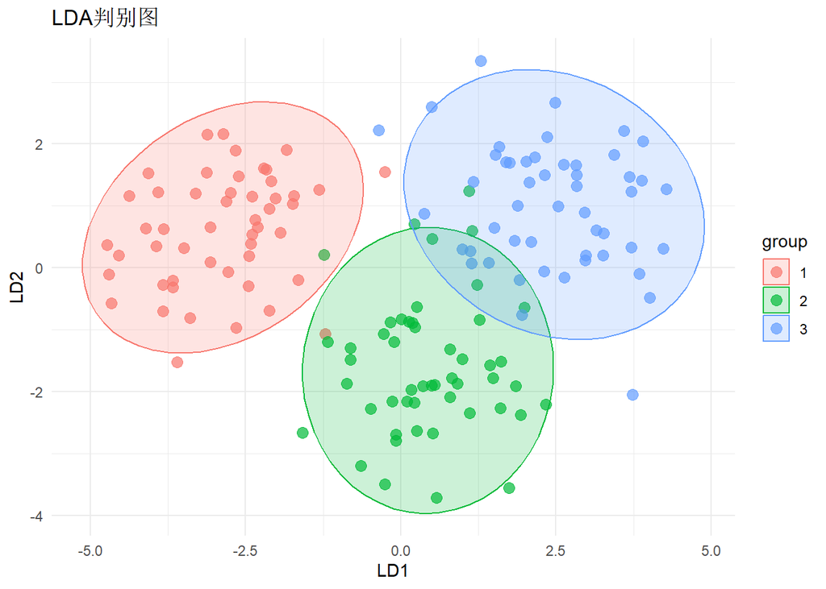

```r
# 可视化判别结果
lda_df <- data.frame(
  LD1 = predict(lda_model)$x[, 1],
  LD2 = predict(lda_model)$x[, 2],
  group = disease_data$group
)
ggplot2::ggplot(lda_df, ggplot2::aes(x = LD1, y = LD2, color = group, fill = group)) +
  ggplot2::geom_point(size = 3, alpha = 0.7) +
  ggplot2::stat_ellipse(geom = "polygon", alpha = 0.2, level = 0.95) +
  ggplot2::labs(title = "LDA判别图", x = "LD1", y = "LD2") +
  ggplot2::theme_minimal()
```